# Project_tidy

Martin S. Bjørnerem

9 desember 2018

## Vårt prosjekt: Bitcoin og aksjemarkeder

### Introduksjon

Hva vi ønsker å gjøre, hvordan, hvilke data, innhentingsmetoder, utvikling i oppgaven underveis.

Vi ønsker å undersøke om prisutviklingen på bitcoin påvirker kursene på verdens aksjemarkeder. Vi har hentet daglig data for bitcoin i USD (BTC/USD) og s&p500 så langt bak i tid som mulig. Siden BTC kan kjøpes og selges hele uka, også i helgene, har vi valgt å fjerne observasjoner lørdager og søndager slik at vi kan “matche”" datasettene. En alternativ løsning er ukentlig data.

### Første blikk/intrykk av bitcoin data

```
##       Date                 BTC
##  Min.   :2012-02-02   Min.   :    0.0
##  1st Qu.:2013-10-09   1st Qu.:  138.6
##  Median :2015-06-18   Median :  438.7
##  Mean   :2015-06-22   Mean   : 1857.0
##  3rd Qu.:2017-03-09   3rd Qu.: 1125.3
##  Max.   :2018-11-14   Max.   :19187.0
```

```
## # A tibble: 4 x 2
##   Date         BTC
##   <date>     <dbl>
## 1 2016-08-03     0
## 2 2016-08-04     0
## 3 2016-08-05     0
## 4 2016-08-06     0
```

```
## # A tibble: 7 x 3
##   day      mean median
##   <fct>   <dbl>  <dbl>
## 1 fredag  1852.   442.
## 2 lørdag  1868.   440.
## 3 mandag  1861.   440.
## 4 onsdag  1865.   443.
## 5 søndag  1859.   434.
## 6 tirsdag 1863.   436.
## 7 torsdag 1852.   432.
```

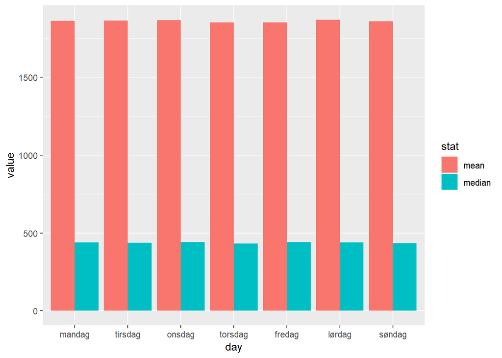

```
##       Date                  SP
##  Min.   :1970-11-27   Min.   :  62.28
##  1st Qu.:1982-11-22   1st Qu.: 139.06
##  Median :1994-11-10   Median : 469.50
##  Mean   :1994-11-19   Mean   : 785.48
##  3rd Qu.:2006-11-16   3rd Qu.:1265.29
##  Max.   :2018-11-27   Max.   :2930.75
```

```
##       Date                  SH
##  Min.   :2001-11-08   Min.   :1012
##  1st Qu.:2006-03-02   1st Qu.:1668
##  Median :2010-05-31   Median :2397
##  Mean   :2010-06-02   Mean   :2490
##  3rd Qu.:2014-09-06   3rd Qu.:3090
##  Max.   :2018-12-07   Max.   :6092
```

```
## # A tibble: 3,174 x 4
##    Date         BTC index verdi
##    <date>     <dbl> <chr> <dbl>
##  1 2012-02-02   6.1 SP    1326.
##  2 2012-02-03   6   SP    1345.
##  3 2012-02-06   5.4 SP    1344.
##  4 2012-02-07   5.7 SP    1347.
##  5 2012-02-08   5.6 SP    1350.
##  6 2012-02-09   5.8 SP    1352.
##  7 2012-02-10   5.9 SP    1343.
##  8 2012-02-13   5.3 SP    1352.
##  9 2012-02-14   4.5 SP    1350.
## 10 2012-02-15   4.3 SP    1343.
## # ... with 3,164 more rows
```

## S&P 500 og BTC

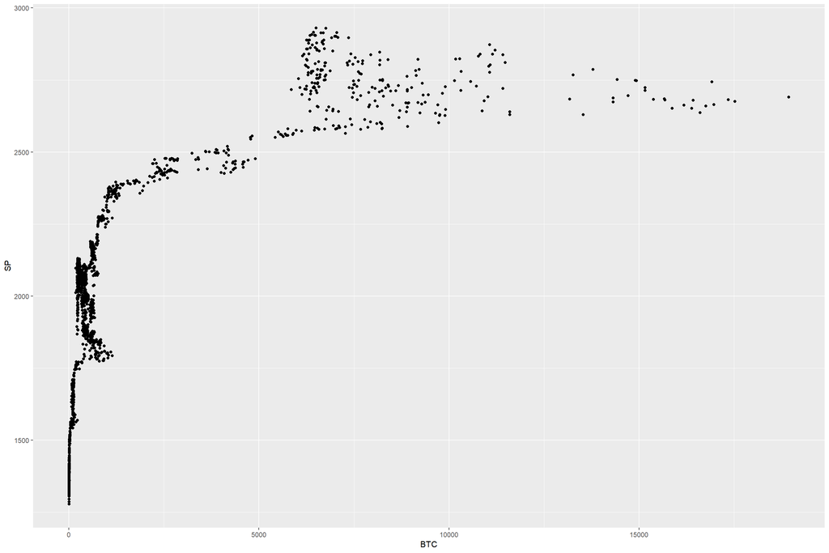

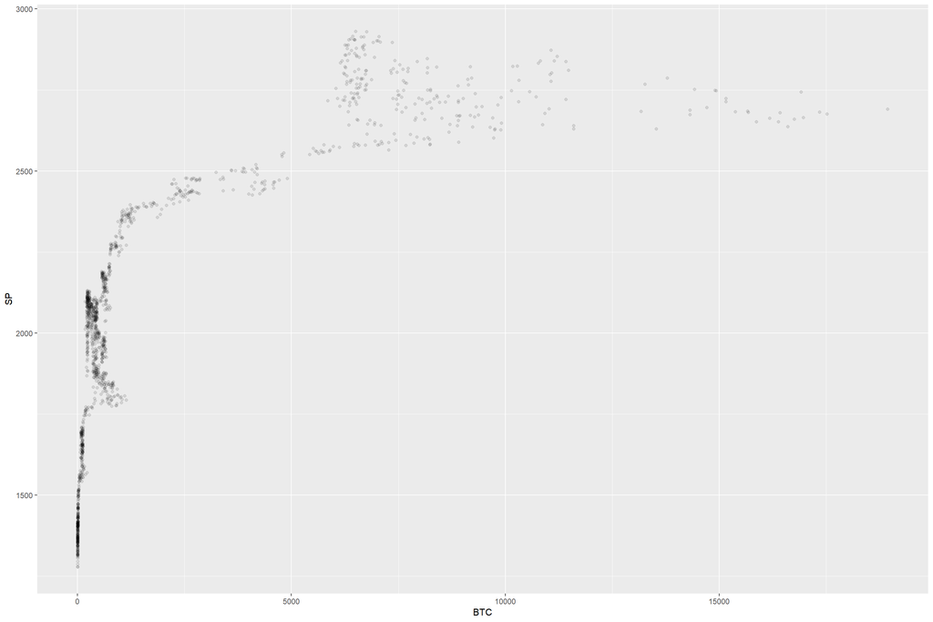

```
##
## Call:
## lm(formula = SP ~ log(BTC), data = ukedager)
##
## Residuals:
##     Min      1Q  Median      3Q     Max
## -458.80  -82.06   25.51   91.56  345.30
##
## Coefficients:
##             Estimate Std. Error t value Pr(>|t|)
## (Intercept)  897.544     10.691   83.95   <2e-16 ***
## log(BTC)     192.252      1.691  113.71   <2e-16 ***
## ---
## Signif. codes:  0 '***' 0.001 '**' 0.01 '*' 0.05 '.' 0.1 ' ' 1
##
## Residual standard error: 141.7 on 1585 degrees of freedom
## Multiple R-squared:  0.8908, Adjusted R-squared:  0.8907
## F-statistic: 1.293e+04 on 1 and 1585 DF,  p-value: < 2.2e-16
```

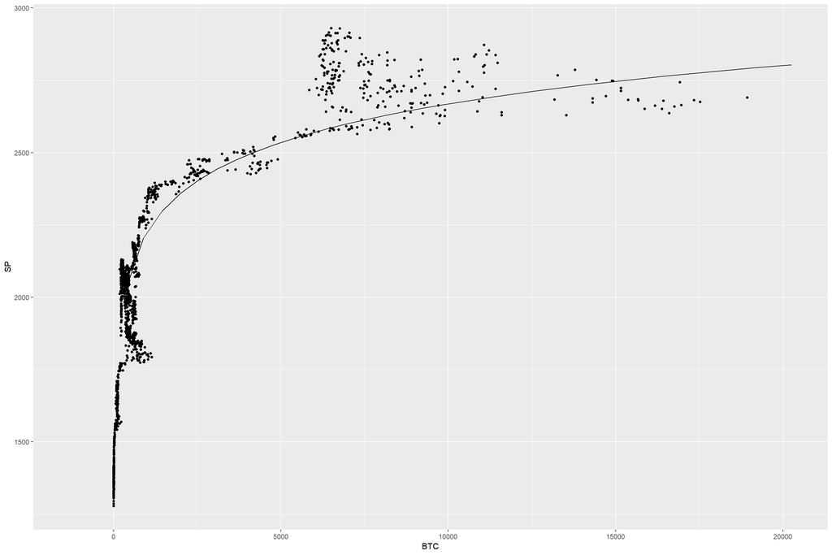

```
## [1] 0.9438229
```

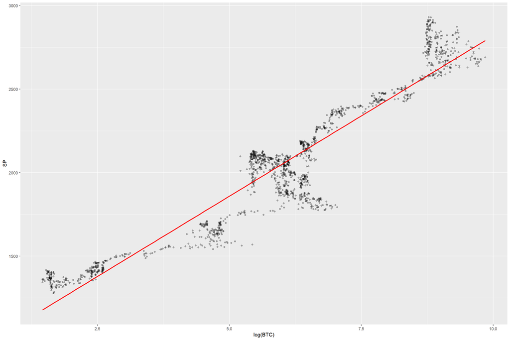

Vi ser at variablene er relaterte, men at forholdet ikke er lineært. En lineær modell vil derfor ikke passe for tidsintervallet. S&P 500 mot log(BTC) gir en mye bedre fit. Vi kan lage en lineær modell for S&P som utrykk av logaritmeverdiene av bitcoin. I enkelte ggplot-grafer er en svært lav alpha benyttet for å vise den ekstreme overplottingen i nedre venstre hjørne.

Positiv korrelasjon innebærer at når den ene variabelen øker, øker også den andre. Styrken i forholdet er lik korrelasjonskoeffisienten, som er 0.94. Korrelasjonen er svært sterk og ikke langt unna perfekt. Ved perfekt korrelasjon er koeffisienten?? lik 1.

Hva sier regresjonsmodellen? R-squared er 0.89. 89% av variasjon i S&P 500 kan forklares av variasjon i log(BTC). For lineære modeller med kun en uavhengig variabel er verdien lik korrelasjonskoeffesienten opphøyet i 2.

Vi er interessert i å se hvordan forholdet og korrelasjonen mellom S&P 500 og log av BTC har utviklet seg over tid.

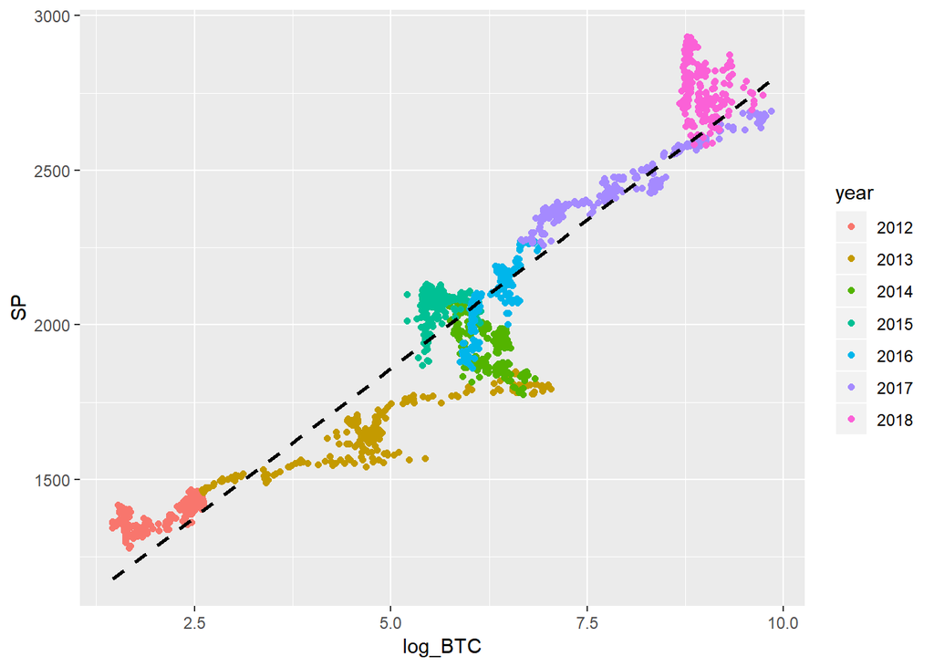

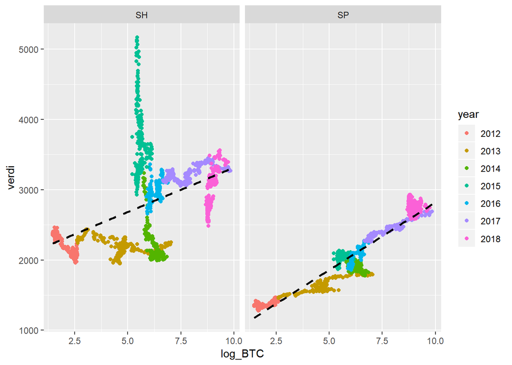

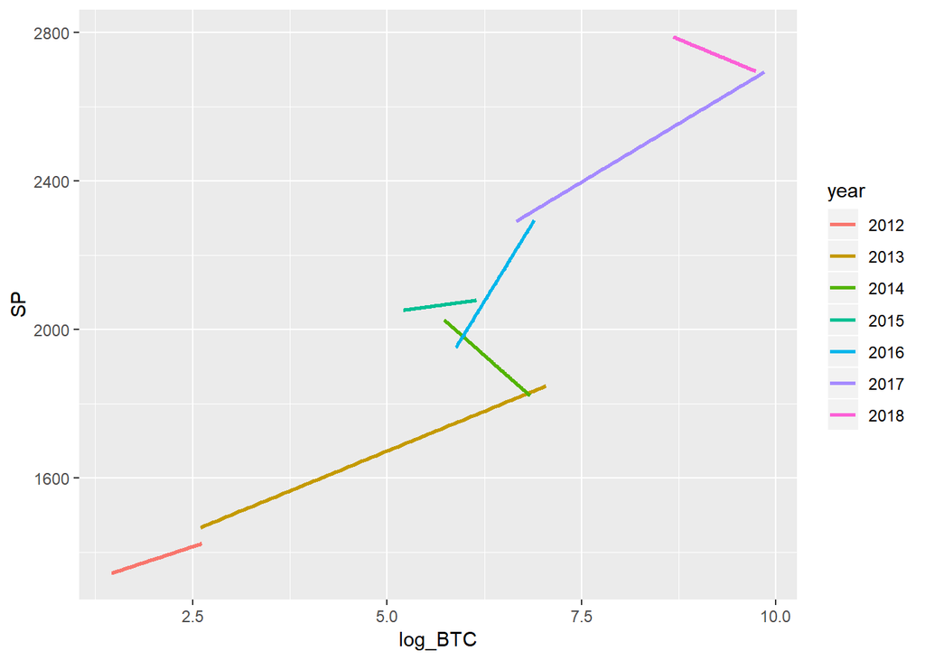

Fra grafen ser vi at regresjonslinja har negativt stigningstall i to årstall, 2014 og 2018. Begge de to årene opplevde bitcoin at “bobla sprakk”.

# Glidende korrelasjon

Vi har benyttet 200 dagers glidende korrelasjon. Korrelasjonen på 200 dager flyttes mot høyre. Enhver observasjonen er et resultat av de siste 200 dagene. De 200 første observasjonene “forsvinner” dermed da de ikke har en verdi.

```
## [1] 0.9438229
```

```
## [1] 0.421458
```

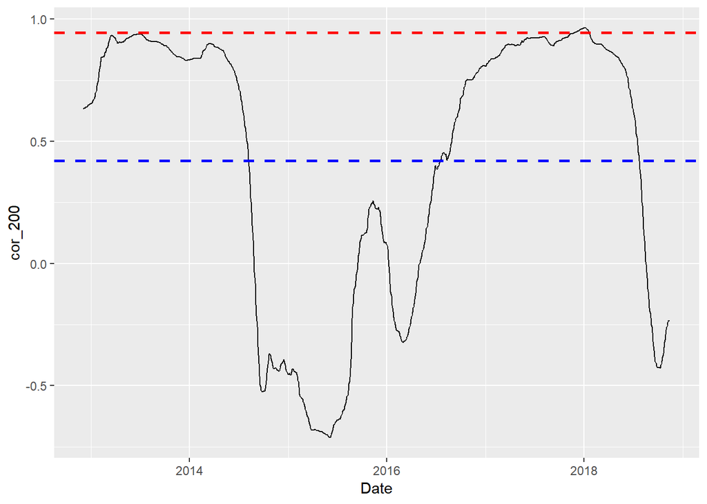

## Multippel regresjonsmodell:

```
## # A tibble: 6 x 7
##   Date        ch1y   oil  us3m    SH    SP   BTC
##   <date>     <dbl> <dbl> <dbl> <dbl> <dbl> <dbl>
## 1 2018-11-14  2.60  56.2  2.38 2632. 2702. 6359.
## 2 2018-11-13  2.62  55.7  2.35 2655. 2722. 6464.
## 3 2018-11-12  2.66  59.9  2.36 2631. 2726. 6447.
## 4 2018-11-09  2.69  60.2  2.36 2599. 2781. 6420.
## 5 2018-11-08  2.72  60.7  2.36 2636. 2807. 6480.
## 6 2018-11-07  2.76  61.7  2.36 2641. 2814. 6573.
```

```
##
## Call:
## lm(formula = SP ~ oil + us3m + log(BTC), data = multi)
##
## Residuals:
##      Min       1Q   Median       3Q      Max
## -306.031  -55.620   -2.894   61.222  210.855
##
## Coefficients:
##              Estimate Std. Error t value Pr(>|t|)
## (Intercept) 1425.2414    18.4939   77.06   <2e-16 ***
## oil           -3.5364     0.1108  -31.92   <2e-16 ***
## us3m         204.3407     6.2844   32.52   <2e-16 ***
## log(BTC)     129.2427     2.6868   48.10   <2e-16 ***
## ---
## Signif. codes:  0 '***' 0.001 '**' 0.01 '*' 0.05 '.' 0.1 ' ' 1
##
## Residual standard error: 89.72 on 1401 degrees of freedom
## Multiple R-squared:  0.9438, Adjusted R-squared:  0.9437
## F-statistic:  7846 on 3 and 1401 DF,  p-value: < 2.2e-16
```

En multippel regresjonsanalyse av S&P 500 med amerikansk oljepris, rente på 3-måneders amerikanske statsobligasjoner og transformerte verdier av bitcoin som uavhengige variabler. R-squared for modellen er 0.94, dette er høyere enn ved bitcoin som eneste faktor.

## Oppsummering av S&P 500 og BTC

S&P 500 er sterkt korrelert med BTC. Transformering av bitcoinprisen til logaritmeverdier viser en sterk og positiv korrelasjon.

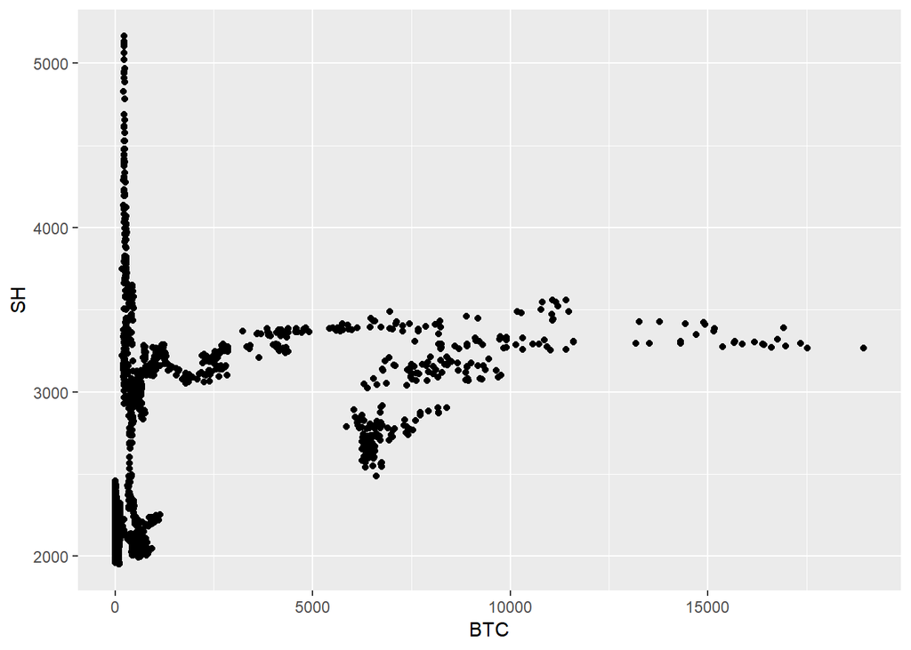

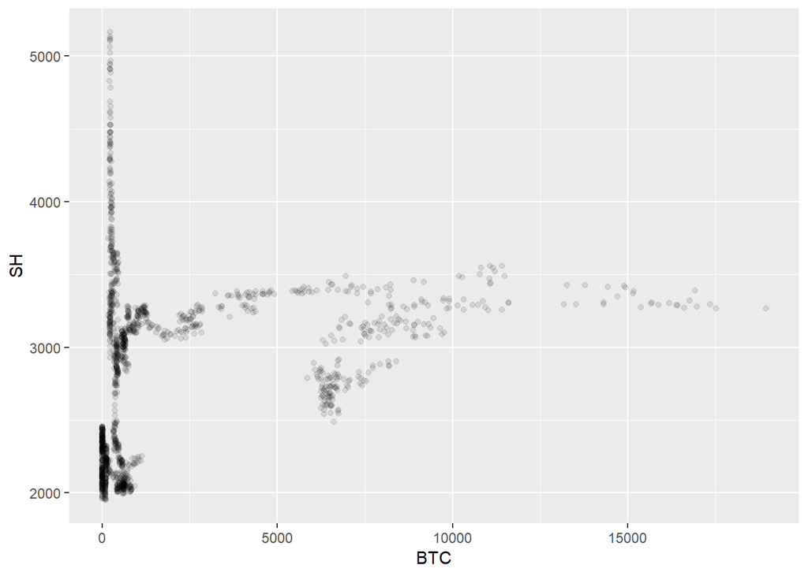

```
##
## Call:
## lm(formula = SH ~ log(BTC), data = ukedager)
##
## Residuals:
##     Min      1Q  Median      3Q     Max
## -890.17 -418.96   26.66  233.07 2427.46
##
## Coefficients:
##             Estimate Std. Error t value Pr(>|t|)
## (Intercept) 2051.507     42.579   48.18   <2e-16 ***
## log(BTC)     126.462      6.734   18.78   <2e-16 ***
## ---
## Signif. codes:  0 '***' 0.001 '**' 0.01 '*' 0.05 '.' 0.1 ' ' 1
##
## Residual standard error: 564.1 on 1585 degrees of freedom
## Multiple R-squared:  0.182,  Adjusted R-squared:  0.1815
## F-statistic: 352.7 on 1 and 1585 DF,  p-value: < 2.2e-16
```

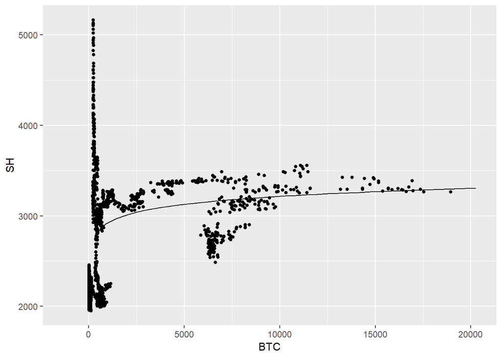

```
## [1] 0.4266502
```

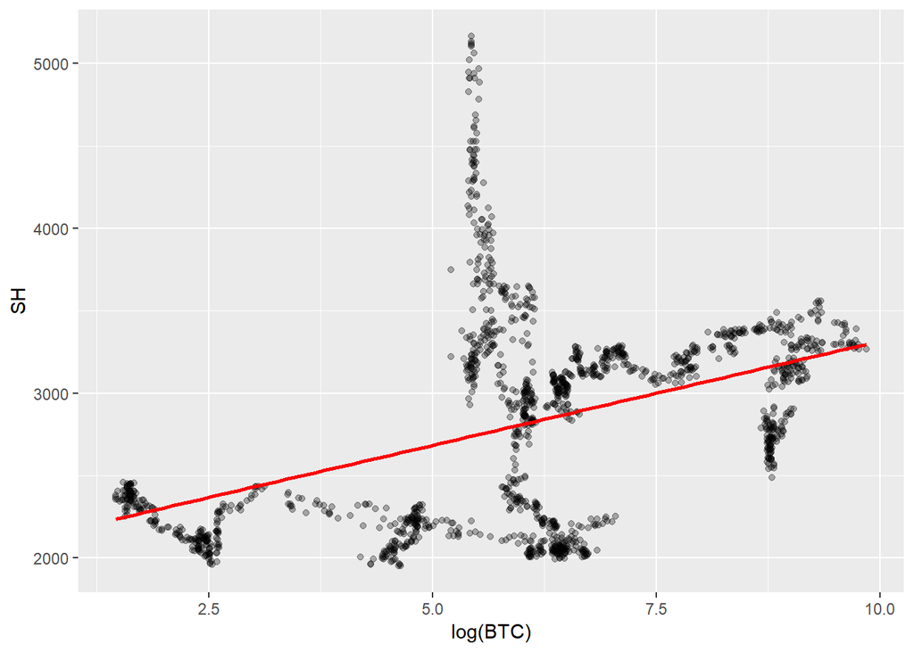

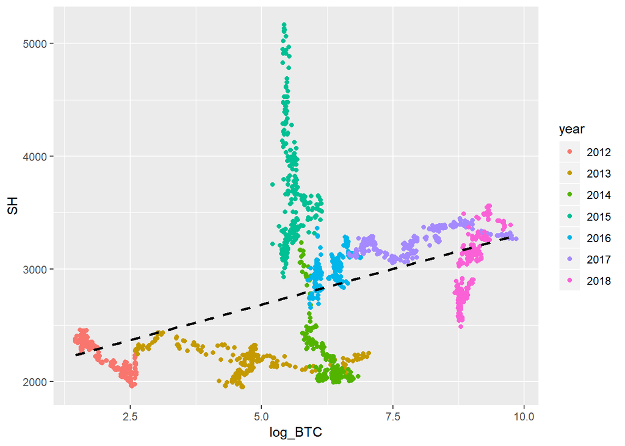

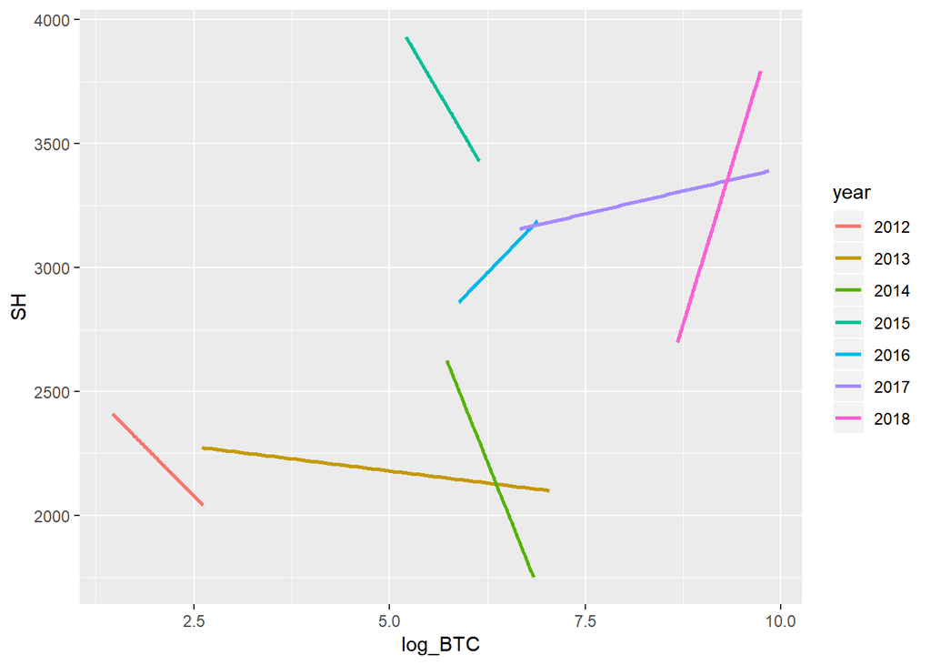

```
## [1] 0.4266502
```

```
## [1] -0.05814605
```

[figure not shown]

```
##
## Call:
## lm(formula = SH ~ oil + ch1y + log(BTC), data = multi)
##
## Residuals:
##     Min      1Q  Median      3Q     Max
## -905.33 -190.41  -47.47  108.52 2073.40
##
## Coefficients:
##              Estimate Std. Error t value Pr(>|t|)
## (Intercept) 4173.6820    68.2225  61.178  < 2e-16 ***
## oil          -18.9291     0.6622 -28.586  < 2e-16 ***
## ch1y         -89.6643    26.6032  -3.370 0.000771 ***
## log(BTC)      38.6689     8.0659   4.794 1.81e-06 ***
## ---
## Signif. codes:  0 '***' 0.001 '**' 0.01 '*' 0.05 '.' 0.1 ' ' 1
##
## Residual standard error: 397.1 on 1401 degrees of freedom
## Multiple R-squared:  0.5979, Adjusted R-squared:  0.5971
## F-statistic: 694.5 on 3 and 1401 DF,  p-value: < 2.2e-16
```